# Air Passengers Time Series Example

Moaeed Sajid

09/01/2019

## EDA

Time Series Data can be modelled using the ARIMA model. ARIMA stands for Auto Regressive Integrated Moving Average.

Auto Regression suggests that the current value is dependent on it’s preceding values. so if the current value is x(t) then the AR component is x(t-1)*a where a is the fitted co-efficient

These previous terms are referred to as lag values (first, second…) which we will see later on.

We will be using the Passengers dataset from the built in R forecasts library.

Model validation will be done using the Ljung-Box test

```r
class("AirPassengers")
```

```
## [1] "character"
```

```r
start (AirPassengers)
```

```
## [1] 1949    1
```

```r
end(AirPassengers)
```

```
## [1] 1960   12
```

```r
frequency(AirPassengers)
```

```
## [1] 12
```

```r
sum(is.na(AirPassengers))
```

```
## [1] 0
```

```r
summary(AirPassengers)
```

```
##    Min. 1st Qu.  Median    Mean 3rd Qu.    Max.
##   104.0   180.0   265.5   280.3   360.5   622.0
```

```r
AirPassengers
```

```
##      Jan Feb Mar Apr May Jun Jul Aug Sep Oct Nov Dec
## 1949 112 118 132 129 121 135 148 148 136 119 104 118
## 1950 115 126 141 135 125 149 170 170 158 133 114 140
## 1951 145 150 178 163 172 178 199 199 184 162 146 166
## 1952 171 180 193 181 183 218 230 242 209 191 172 194
## 1953 196 196 236 235 229 243 264 272 237 211 180 201
## 1954 204 188 235 227 234 264 302 293 259 229 203 229
## 1955 242 233 267 269 270 315 364 347 312 274 237 278
## 1956 284 277 317 313 318 374 413 405 355 306 271 306
## 1957 315 301 356 348 355 422 465 467 404 347 305 336
## 1958 340 318 362 348 363 435 491 505 404 359 310 337
## 1959 360 342 406 396 420 472 548 559 463 407 362 405
## 1960 417 391 419 461 472 535 622 606 508 461 390 432
```

## Plot with Trend Line using lm

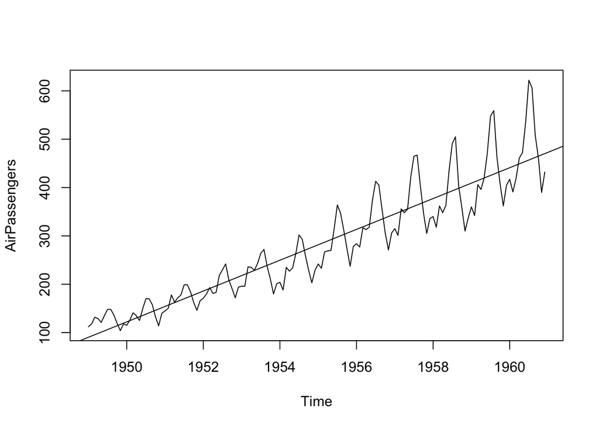

```r
plot(AirPassengers)
abline(reg=lm(AirPassengers~time(AirPassengers)))
```

```r
cycle(AirPassengers)
```

```
##      Jan Feb Mar Apr May Jun Jul Aug Sep Oct Nov Dec
## 1949   1   2   3   4   5   6   7   8   9  10  11  12
## 1950   1   2   3   4   5   6   7   8   9  10  11  12
## 1951   1   2   3   4   5   6   7   8   9  10  11  12
## 1952   1   2   3   4   5   6   7   8   9  10  11  12
## 1953   1   2   3   4   5   6   7   8   9  10  11  12
## 1954   1   2   3   4   5   6   7   8   9  10  11  12
## 1955   1   2   3   4   5   6   7   8   9  10  11  12
## 1956   1   2   3   4   5   6   7   8   9  10  11  12
## 1957   1   2   3   4   5   6   7   8   9  10  11  12
## 1958   1   2   3   4   5   6   7   8   9  10  11  12
## 1959   1   2   3   4   5   6   7   8   9  10  11  12
## 1960   1   2   3   4   5   6   7   8   9  10  11  12
```

## Time Series Decompostition

The plot below shows the observed data, overall trend, seasonal variation and the the irregularity.

Before building a time series model the data needs to be stationary. That is that it needs to have a constant mean and variance.

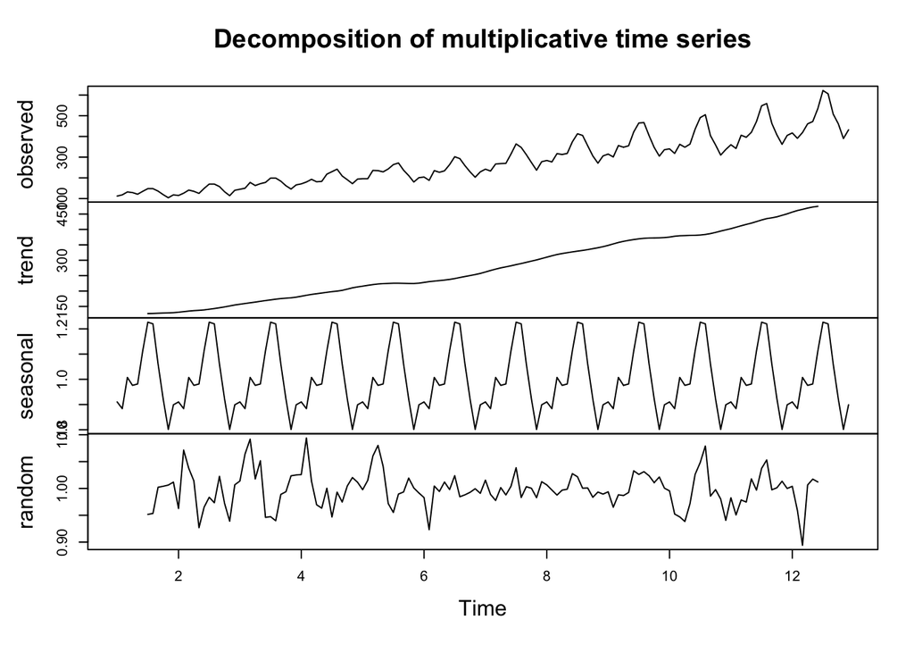

```r
tsdata <- ts(AirPassengers, frequency = 12)
ddata <- decompose(tsdata, type = "multiplicative")
plot(ddata)
```

```r
#plot(ddata$trend/type/seasonal/random)
```

## Boxplot by Cycle

Shows much more passengers during Jun-Sep

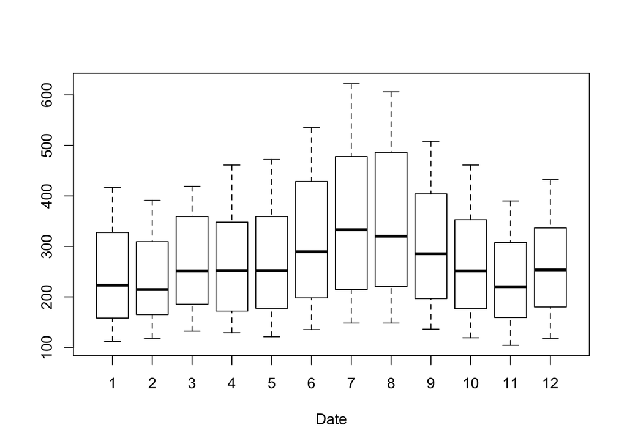

```r
boxplot(AirPassengers~ cycle(AirPassengers), xlab = "Date")
```

## Identify PDQ

Use the auto.arima method in R to identify best values to use for ARIMA, thefirst set of brackets.

- AR(p) is the number of Auto Regressive Terms
- I(d) the degree of differencing is how many non seasonal differences are required to achieve stationarity
- MA(q) is the error of the model as a combination of previous error terms e<sub>t</sub>

Second set are about seasonality

```r
auto.arima(AirPassengers, ic = "aic", trace = TRUE)
```

```
##
##  ARIMA(2,1,2)(1,1,1)[12]                    : Inf
##  ARIMA(0,1,0)(0,1,0)[12]                    : 1031.508
##  ARIMA(1,1,0)(1,1,0)[12]                    : 1020.393
##  ARIMA(0,1,1)(0,1,1)[12]                    : 1021.003
##  ARIMA(1,1,0)(0,1,0)[12]                    : 1020.394
##  ARIMA(1,1,0)(2,1,0)[12]                    : 1019.24
##  ARIMA(1,1,0)(2,1,1)[12]                    : Inf
##  ARIMA(0,1,0)(2,1,0)[12]                    : 1032.12
##  ARIMA(2,1,0)(2,1,0)[12]                    : 1021.12
##  ARIMA(1,1,1)(2,1,0)[12]                    : 1021.033
##  ARIMA(2,1,1)(2,1,0)[12]                    : 1017.658
##  ARIMA(2,1,1)(1,1,0)[12]                    : 1017.915
##  ARIMA(2,1,1)(2,1,1)[12]                    : Inf
##  ARIMA(3,1,1)(2,1,0)[12]                    : 1019.459
##  ARIMA(2,1,2)(2,1,0)[12]                    : 1019.504
##  ARIMA(3,1,2)(2,1,0)[12]                    : 1021.454
##
##  Best model: ARIMA(2,1,1)(2,1,0)[12]
```

```
## Series: AirPassengers
## ARIMA(2,1,1)(2,1,0)[12]
##
## Coefficients:
##          ar1     ar2      ma1     sar1    sar2
##       0.5741  0.2547  -0.9822  -0.1136  0.1641
## s.e.  0.0899  0.0933   0.0286   0.0963  0.1073
##
## sigma^2 estimated as 129.5:  log likelihood=-502.83
## AIC=1017.66   AICc=1018.34   BIC=1034.91
```

```r
myFit <- auto.arima(AirPassengers)
myFit
```

```
## Series: AirPassengers
## ARIMA(2,1,1)(0,1,0)[12]
##
## Coefficients:
##          ar1     ar2      ma1
##       0.5960  0.2143  -0.9819
## s.e.  0.0888  0.0880   0.0292
##
## sigma^2 estimated as 132.3:  log likelihood=-504.92
## AIC=1017.85   AICc=1018.17   BIC=1029.35
```

## Checking the model

Plot the…

- Residuals

In order to test wether the data is stationary we can use the following 2 parameters

- Auto Correlation Function Used to determine how past and future points are related in a time series by showing how correlated points are with each other, based on on how many time steps they are separated
- Partial Auto Correlation Function The degree of association between two variables whilst adjusting the effect ofone or more additional variables.

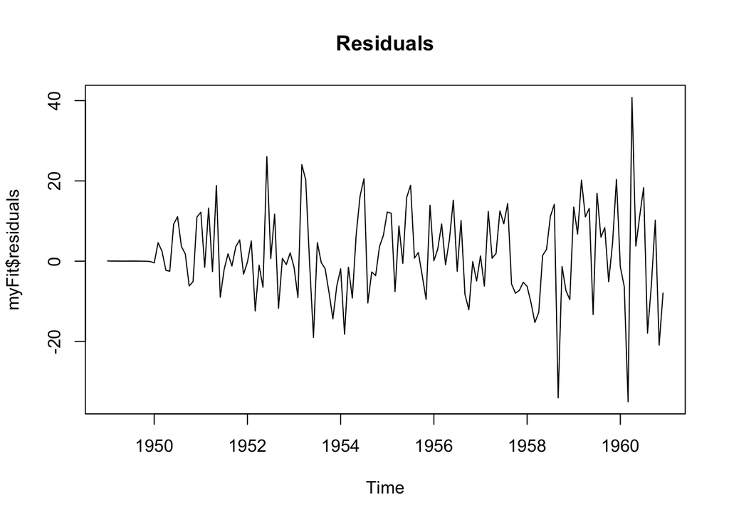

```r
library(tseries)
plot.ts(myFit$residuals, main = "Residuals")
```

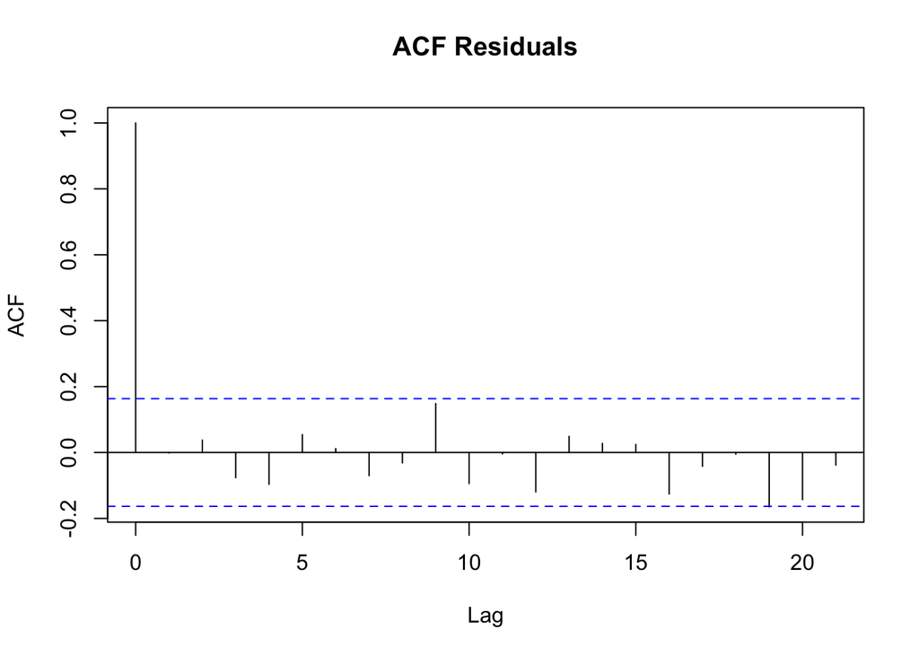

```r
acf(ts(myFit$residuals), main = "ACF Residuals")
```

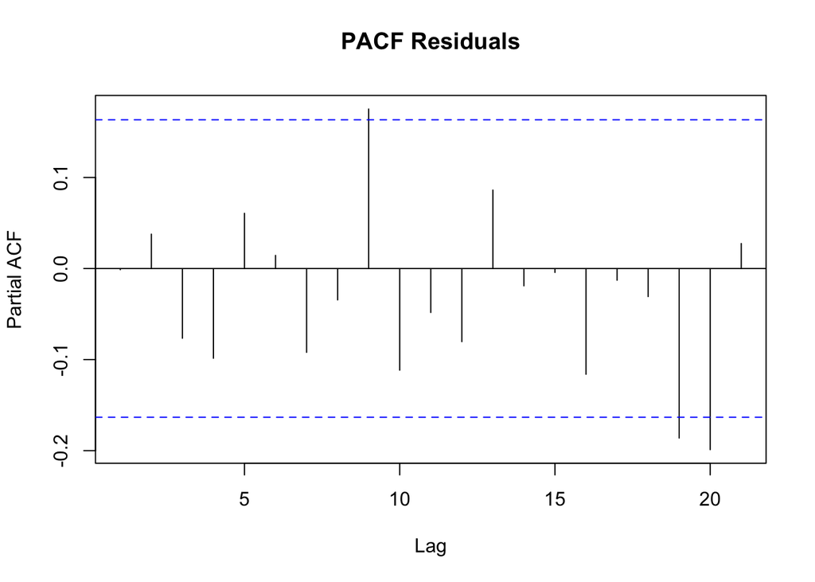

```r
pacf(ts(myFit$residuals), main = "PACF Residuals")
```

## Predicting the model

h in forecast command will decide how far ahead to forecast

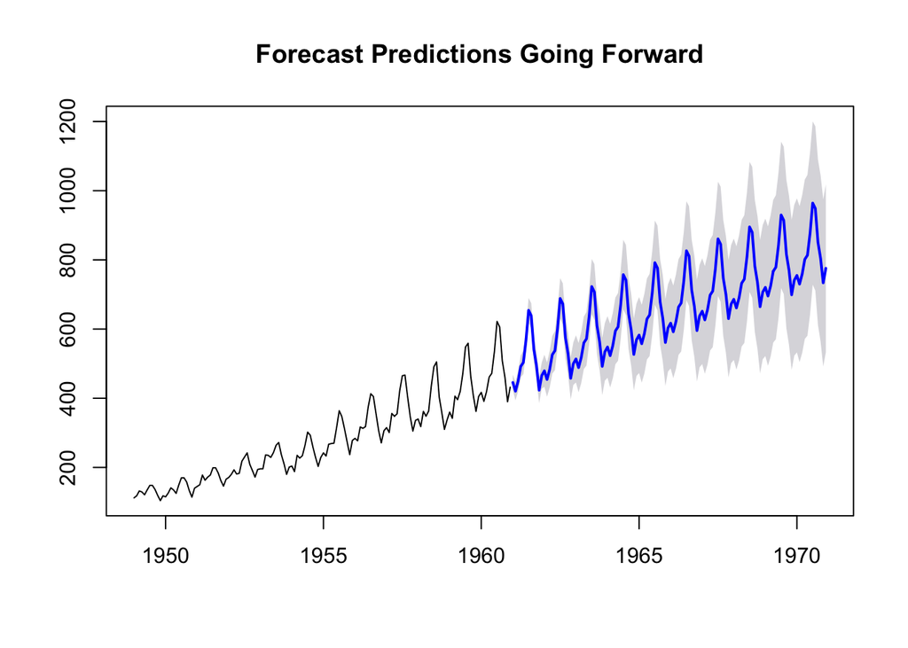

```r
apForecast <- forecast(myFit, level = 95,h = 10*12)
plot(apForecast, main = "Forecast Predictions Going Forward")
```

## Testing the model using box-test

Box test below gives us p values which are relatively high showing the model to be accurate

```r
Box.test(myFit$residuals, lag = 5, type = "Ljung-Box")
```

```
##
##  Box-Ljung test
##
## data:  myFit$residuals
## X-squared = 2.9244, df = 5, p-value = 0.7116
```

```r
Box.test(myFit$residuals, lag = 10, type = "Ljung-Box")
```

```
##
##  Box-Ljung test
##
## data:  myFit$residuals
## X-squared = 8.6878, df = 10, p-value = 0.562
```

```r
Box.test(myFit$residuals, lag = 15, type = "Ljung-Box")
```

```
##
##  Box-Ljung test
##
## data:  myFit$residuals
## X-squared = 11.582, df = 15, p-value = 0.7104
```